# A3: SPL Library Checkouts

### Introduction

The data I chose to analyze is Seattle Public Library’s checkout data for items that have been checked out at least 10 times a month from 2017-2023. This data offered insight into what items were the most popular to library users, as well as reveal the trend on the popularity of those items for the past six years. I wanted to see if worldwide events like the pandemic and BLM movement influenced the items that were most frequently checked out in libraries.

### Summary Information

From 2017 to 2023, there were 99545 unique items that were checked out more 10 times each month from the Seattle Public Libraries. Of those 99545 unique items, 61137 were physical items, and 38408 were digital items. The month with the highest number of checkouts was 2019-01-01 (ignoring the day value), where there was a total of 340175 checkouts for items that were checked out 10+ times monthly. On the other hand, the month with the least checkouts for these items was 2020-04-01 (ignoring the day value), where there was a total of 140861 checkouts.

During the time frame of 2017 to 2023, the most checked out item in a singular month was the AUDIOBOOK, So You Want to Talk about Race (Unabridged) by Ijeoma Oluo. It was checked out 4903 times in the month of 2020-06-01 (ignoring the day value). I found this data very interesting because the time coincided with the BLM movement that took place worldwide, so it was cool to see how the library checkout data reflected what was going on in our society.

### The Dataset

The dataset, Checkouts by Title, is collected and provided by the Seattle Public Library. The data consists of monthly counts of checkout for an item in the library, and provides information on the item’s title, creator, publisher, material type, checkout times, and more. The SPL collects this data from various sources. For digital checkouts, the data comes from the media vendors, such as Overdrive, hoopla, Freegal, and RBDigital. For physical checkouts, they source the data from the Legrady artwork data archives for checkouts during April 2005 to September 30, 2016, and from Horizon ILS for checkouts during October 1, 2016 to now.

This data was collected to keep track of library checkout items on a monthly basis. This allows the SPL as well as the public to see what items are more commonly checked out and what aren’t. However, some ethical questions to consider with this data is whether any user privacy was violated. By collecting the data on checkout rate, is the library also keeping track of which users are checking out those materials? If so, even if that data isn’t explicitly used or stored, there are still implications to a library user’s privacy if their media consumption is being tracked.

Possible limitations with this data is that it doesn’t really reflect the consumption rates of each item. Just because an item is checked out doesn’t mean the user actually read/watched/listened to the item, and so the checkout rates cannot be used as an accurate indicator for assessing whether a title has been consumed. Also, we don’t know if it’s the same users checking out an item or if those checkouts are by unique users, so it also doesn’t reflect how many distinct individuals have checked out an item. In addition, the SPL indicates that this dataset only keeps track of the initial checkout rates, so if an item has been renewed (extending their due date), that is not something the system keeps track of. With all these little plotholes in the dataset, it limits our understanding of the true consumption rates of these library items.

For this analysis, I specifically chose a subset of this dataset which only includes data for items that have been checked out at least 10 times a month from 2017-2023. In this dataset, there are a total of 816354 observations (rows) where each row is a singular item, and 12 variables (columns) that contains the information for that specific item.

### Chart 1: Average Checkout Rates over Time

The first chart shows the average number of checkouts of a single item in a month for items that have been checked out for 10+ times monthly. I wanted to look at the average checkout times for popular library items over time to see when there were higher checkout rates, and to visually show that trend I displayed the data through a line chart. Based on the line chart, I found that June of 2020 had the highest average checkout times for single items, with an average of 28.9 checkouts each month for one item. This was an interesting finding because this was also the time when the pandemic was in its peak and people were quarantined indefinitely, so it made sense to see an increase in the average checkout rates around that time period.

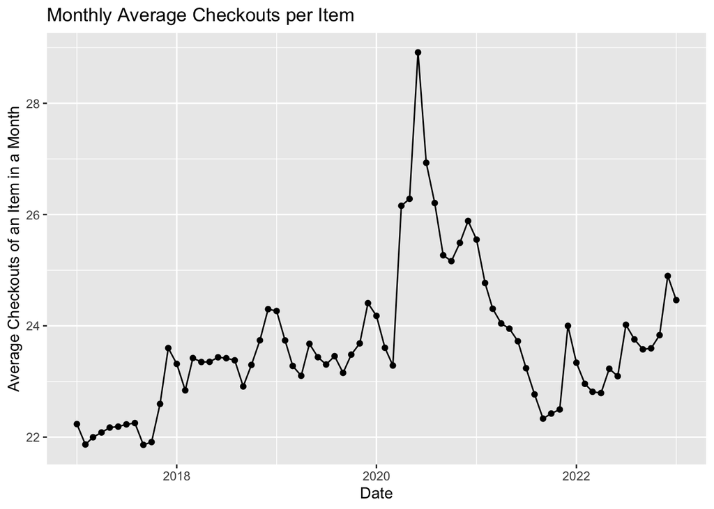

### Chart 2: Types of Items Checked Out over Time

The second chart showed the total number of checkouts for items that have been checked out 10+ times monthly over the past six years (2017-2023) and their composition of whether the items were physical or digital materials. Based on this bar graph, We can see that generally there are a total of around 3 million total checkouts for these items each year, which the 2023 data being a bit of an outlier since the year just started. However, I found it super interesting that the composition of those checkouts based on material type had a drastic change starting in 2020. The Covid-19 pandemic shifted much of our world’s operations an online model, and that is also reflected in this checkout data. Before 2020, the majority of checkouts were physical items, but starting in 2020, the majority of checkouts were digital items.

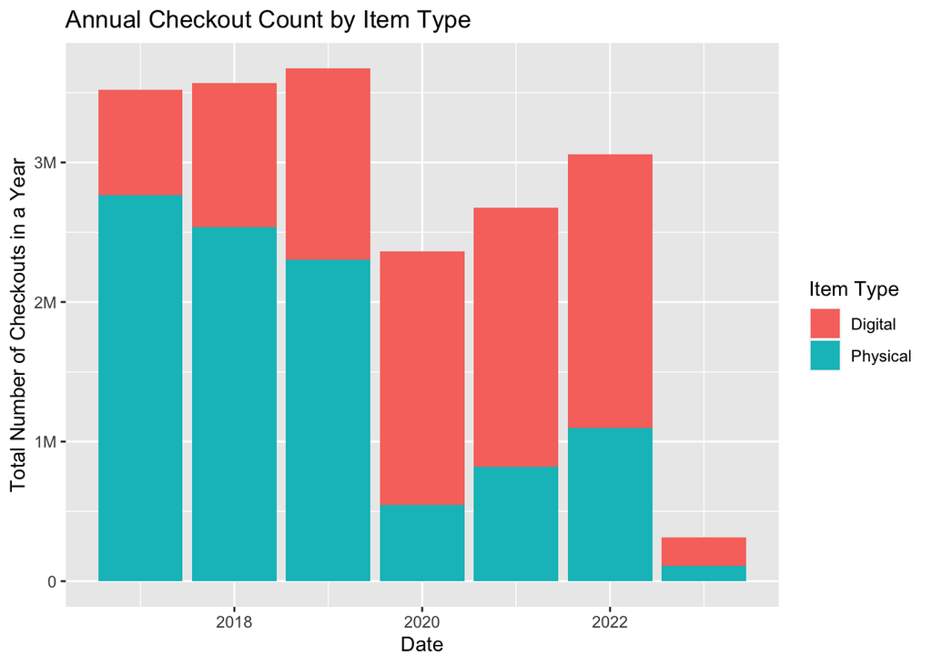

### Chart 3: Most Chekced Out Material Types

The last chart I analyzed was a piechart that showed the composition of all the checkouts from 2017-2023 based on their material type. I chose to examine this data because I think libraries are typically associated with borrowing books, but libraries actually offer a much wider medium of materials. The Seattle Public Library offers 32 types of items to checkout, and this piechart shows the top 10 most checked out material types. From the chart, we can see that the four most checked out material type are audiobooks, books, eBooks, and videodiscs, each with around 3-6 million checkouts from 2017-2023.

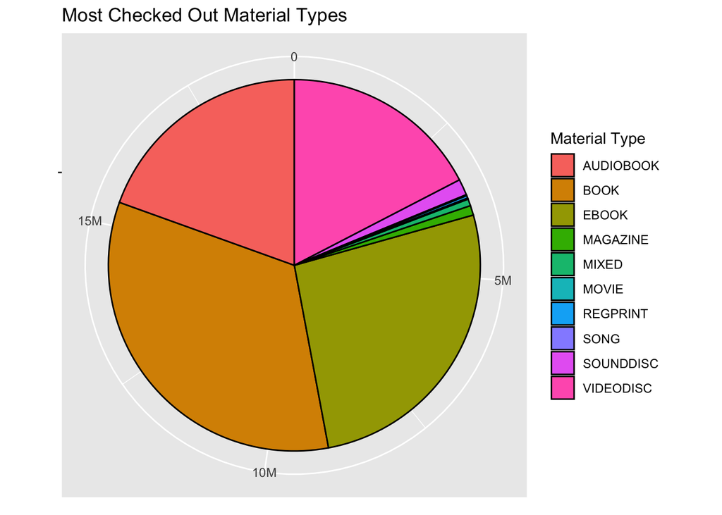